# Application Loading Times

Jacob Igel & Samuel Vaughan

Last complied on April 27, 2023

The IT Department at a large corporation is concerned about the time it takes to load an application across the network. The would like to implement an $\bar{X}$ and $R$ chart so that this time can be monitored and improvements can be made to this loading time. Over the past 25 days, they have randomly selected five application loading and monitored the time from start to completion. The data is contained in the file “loading times.csv”.

1. Read in the data.

```r
df <- read.csv("/Users/jacobigel/Desktop/School/ISA365-A/Datasets/loading times.csv",stringsAsFactors = TRUE)

head(df)
```

```
##   Sample_1 Sample_2 Sample_3 Sample_4 Sample_5
## 1 14.14008 13.51941 15.78508 15.59895 14.62382
## 2 14.70001 14.54917 15.56179 14.06132 14.92635
## 3 14.28013 13.40329 14.16050 14.72617 14.52753
## 4 14.77799 15.00427 14.55313 15.51614 14.43299
## 5 14.83870 14.26560 15.11553 15.32287 15.83024
## 6 15.98733 15.20988 15.76594 15.67847 14.14672
```

2. Construct the R chart and assess if the within day variation is stable.

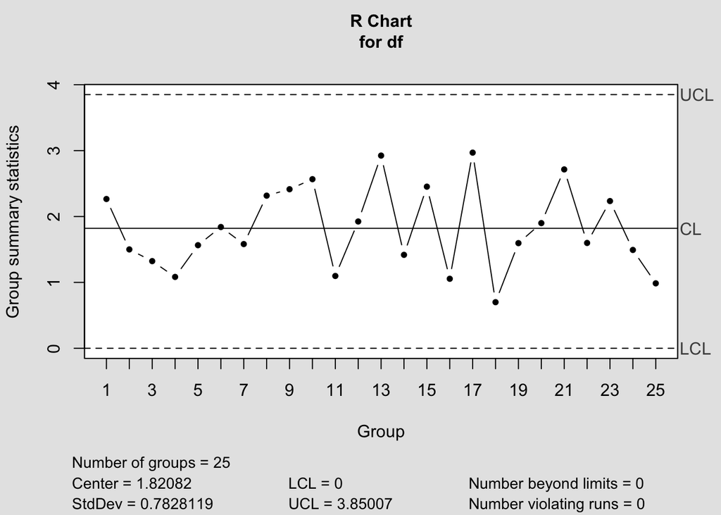

```
## List of 11
##  $ call      : language qcc(data = df, type = "R")
##  $ type      : chr "R"
##  $ data.name : chr "df"
##  $ data      : num [1:25, 1:5] 14.1 14.7 14.3 14.8 14.8 ...
##   ..- attr(*, "dimnames")=List of 2
##  $ statistics: Named num [1:25] 2.27 1.5 1.32 1.08 1.56 ...
##   ..- attr(*, "names")= chr [1:25] "1" "2" "3" "4" ...
##  $ sizes     : int [1:25] 5 5 5 5 5 5 5 5 5 5 ...
##  $ center    : num 1.82
##  $ std.dev   : num 0.783
##  $ nsigmas   : num 3
##  $ limits    : num [1, 1:2] 0 3.85
##   ..- attr(*, "dimnames")=List of 2
##  $ violations:List of 2
##  - attr(*, "class")= chr "qcc"
```

```r
library(qcc)
library(tidyverse)

qcc(df, type="R")
```

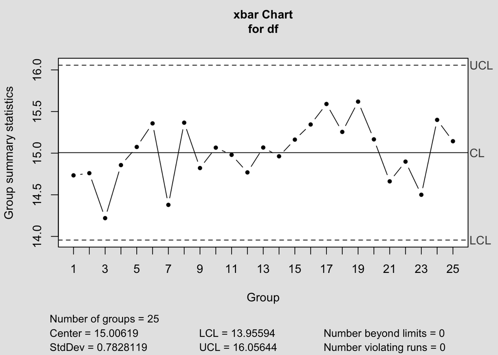

```
## List of 11
##  $ call      : language qcc(data = df, type = "xbar")
##  $ type      : chr "xbar"
##  $ data.name : chr "df"
##  $ data      : num [1:25, 1:5] 14.1 14.7 14.3 14.8 14.8 ...
##   ..- attr(*, "dimnames")=List of 2
##  $ statistics: Named num [1:25] 14.7 14.8 14.2 14.9 15.1 ...
##   ..- attr(*, "names")= chr [1:25] "1" "2" "3" "4" ...
##  $ sizes     : int [1:25] 5 5 5 5 5 5 5 5 5 5 ...
##  $ center    : num 15
##  $ std.dev   : num 0.783
##  $ nsigmas   : num 3
##  $ limits    : num [1, 1:2] 14 16.1
##   ..- attr(*, "dimnames")=List of 2
##  $ violations:List of 2
##  - attr(*, "class")= chr "qcc"
```

```r
qcc(df, type="xbar")
```

- Between day variation looks stable!
4. If both charts show no violations make an estimate of the average application loading time.

```r
mean(rowMeans(df))
```

```
## [1] 15.00619
```

5. The IT department has made some changes that they hope to lower the loading times. They wish to continue to monitor the loading times after these changes. Read in the data “new loading times.csv” and call it something different from the original data.

```r
df.new <- read.csv("/Users/jacobigel/Desktop/School/ISA365-A/Datasets/new loading times.csv",stringsAsFactors = TRUE)

head(df.new)
```

```
##    Sample_1  Sample_2  Sample_3  Sample_4  Sample_5
## 1  9.140078  8.519408 10.785083 10.598952  9.623816
## 2  9.700008  9.549170 10.561791  9.061324  9.926346
## 3  9.280127  8.403287  9.160501  9.726168  9.527533
## 4  9.777987 10.004268  9.553135 10.516141  9.432988
## 5  9.838696  9.265601 10.115529 10.322874 10.830242
## 6 10.987333 10.209875 10.765936 10.678470  9.146724
```

6. Make a chart to assess the changes in the within (R) day variabilty. Add the `newdata=` argument to the `qcc` and assign the data frame you read in above to that object. Comment on any changes in the within day variation.

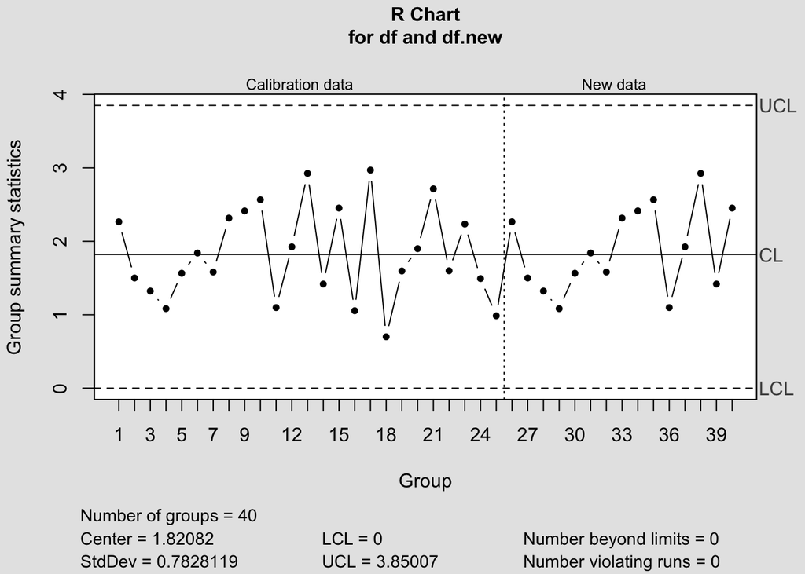

```
## List of 15
##  $ call        : language qcc(data = df, type = "R", newdata = df.new)
##  $ type        : chr "R"
##  $ data.name   : chr "df"
##  $ data        : num [1:25, 1:5] 14.1 14.7 14.3 14.8 14.8 ...
##   ..- attr(*, "dimnames")=List of 2
##  $ statistics  : Named num [1:25] 2.27 1.5 1.32 1.08 1.56 ...
##   ..- attr(*, "names")= chr [1:25] "1" "2" "3" "4" ...
##  $ sizes       : int [1:25] 5 5 5 5 5 5 5 5 5 5 ...
##  $ center      : num 1.82
##  $ std.dev     : num 0.783
##  $ newstats    : Named num [1:15] 2.27 1.5 1.32 1.08 1.56 ...
##   ..- attr(*, "names")= chr [1:15] "26" "27" "28" "29" ...
##  $ newdata     : num [1:15, 1:5] 9.14 9.7 9.28 9.78 9.84 ...
##   ..- attr(*, "dimnames")=List of 2
##  $ newsizes    : int [1:15] 5 5 5 5 5 5 5 5 5 5 ...
##  $ newdata.name: chr "df.new"
##  $ nsigmas     : num 3
##  $ limits      : num [1, 1:2] 0 3.85
##   ..- attr(*, "dimnames")=List of 2
##  $ violations  :List of 2
##  - attr(*, "class")= chr "qcc"
```

```r
qcc(data=df, type="R", newdata=df.new)
```

- From comparing the old df to the new df, there appear to be no obvious changes within day variation.
7. Make a chart to assess the changes in the between (xbar) day variabitliy. Add the `newdata=` argument to the `qcc` and assign the data frame you read in above to that object. Comment on any changes in the loading times after this change.

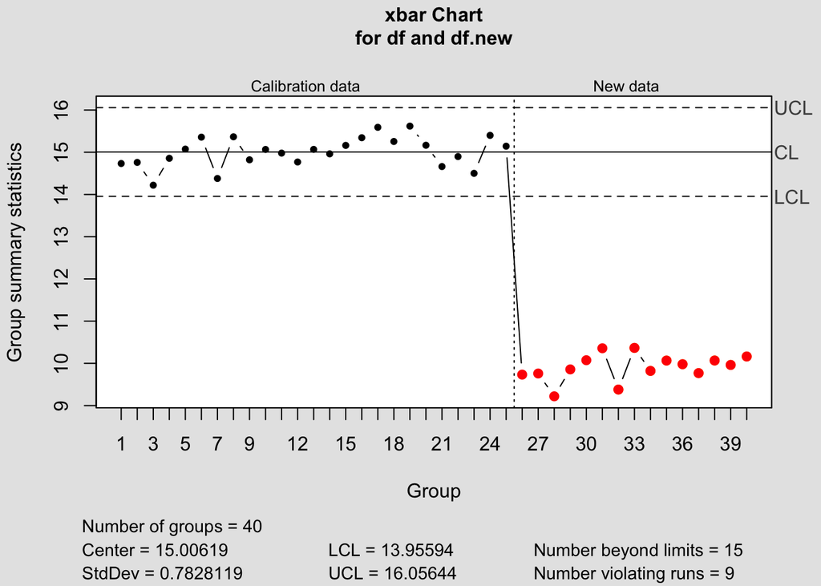

```
## List of 15
##  $ call        : language qcc(data = df, type = "xbar", newdata = df.new)
##  $ type        : chr "xbar"
##  $ data.name   : chr "df"
##  $ data        : num [1:25, 1:5] 14.1 14.7 14.3 14.8 14.8 ...
##   ..- attr(*, "dimnames")=List of 2
##  $ statistics  : Named num [1:25] 14.7 14.8 14.2 14.9 15.1 ...
##   ..- attr(*, "names")= chr [1:25] "1" "2" "3" "4" ...
##  $ sizes       : int [1:25] 5 5 5 5 5 5 5 5 5 5 ...
##  $ center      : num 15
##  $ std.dev     : num 0.783
##  $ newstats    : Named num [1:15] 9.73 9.76 9.22 9.86 10.07 ...
##   ..- attr(*, "names")= chr [1:15] "26" "27" "28" "29" ...
##  $ newdata     : num [1:15, 1:5] 9.14 9.7 9.28 9.78 9.84 ...
##   ..- attr(*, "dimnames")=List of 2
##  $ newsizes    : int [1:15] 5 5 5 5 5 5 5 5 5 5 ...
##  $ newdata.name: chr "df.new"
##  $ nsigmas     : num 3
##  $ limits      : num [1, 1:2] 14 16.1
##   ..- attr(*, "dimnames")=List of 2
##  $ violations  :List of 2
##  - attr(*, "class")= chr "qcc"
```

```r
qcc(data=df, type="xbar", newdata=df.new)
```

- From comparing the old df to the new df, there does appear to be a significant difference in loading times after the change. We can see that the new data has a much lower average mean than the old data.
8. Make a new set of R and Xbar charts using only the new data. This will be the new baseline for the application loading times moving forward. Provide the average loading time.

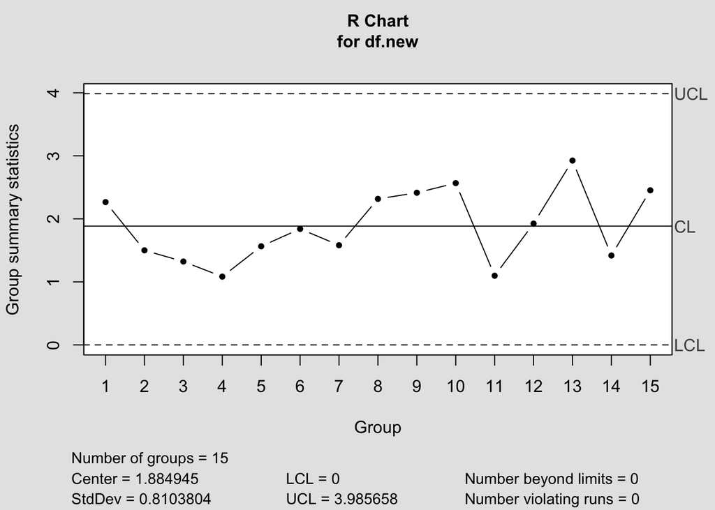

```
## List of 11
##  $ call      : language qcc(data = df.new, type = "R")
##  $ type      : chr "R"
##  $ data.name : chr "df.new"
##  $ data      : num [1:15, 1:5] 9.14 9.7 9.28 9.78 9.84 ...
##   ..- attr(*, "dimnames")=List of 2
##  $ statistics: Named num [1:15] 2.27 1.5 1.32 1.08 1.56 ...
##   ..- attr(*, "names")= chr [1:15] "1" "2" "3" "4" ...
##  $ sizes     : int [1:15] 5 5 5 5 5 5 5 5 5 5 ...
##  $ center    : num 1.88
##  $ std.dev   : num 0.81
##  $ nsigmas   : num 3
##  $ limits    : num [1, 1:2] 0 3.99
##   ..- attr(*, "dimnames")=List of 2
##  $ violations:List of 2
##  - attr(*, "class")= chr "qcc"
```

```r
qcc(df.new, type="R")
```

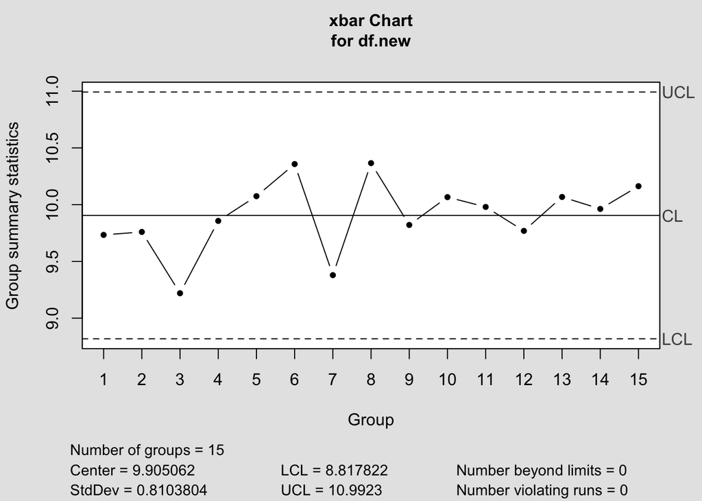

```
## List of 11
##  $ call      : language qcc(data = df.new, type = "xbar")
##  $ type      : chr "xbar"
##  $ data.name : chr "df.new"
##  $ data      : num [1:15, 1:5] 9.14 9.7 9.28 9.78 9.84 ...
##   ..- attr(*, "dimnames")=List of 2
##  $ statistics: Named num [1:15] 9.73 9.76 9.22 9.86 10.07 ...
##   ..- attr(*, "names")= chr [1:15] "1" "2" "3" "4" ...
##  $ sizes     : int [1:15] 5 5 5 5 5 5 5 5 5 5 ...
##  $ center    : num 9.91
##  $ std.dev   : num 0.81
##  $ nsigmas   : num 3
##  $ limits    : num [1, 1:2] 8.82 10.99
##   ..- attr(*, "dimnames")=List of 2
##  $ violations:List of 2
##  - attr(*, "class")= chr "qcc"
```

```r
qcc(df.new, type="xbar")
```

```r
mean(rowMeans(df.new))
```

```
## [1] 9.905062
```

- The average loading time should be 9.905062.